# Project_Scoring_Model_2026

```python
df_app_train_after_handling_outliers=df_numeric.copy()
```

```
Box plot after removal of outliers in SK_ID_CURR column
```

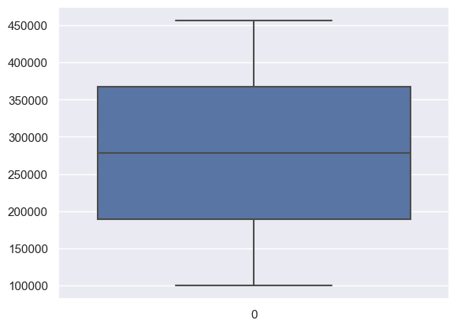

```
Box plot after removal of outliers in CNT_CHILDREN column
```

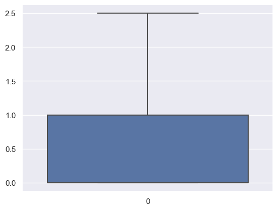

```
Box plot after removal of outliers in AMT_INCOME_TOTAL column
```

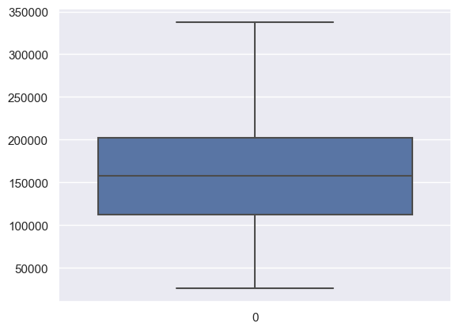

```
Box plot after removal of outliers in AMT_CREDIT column
```

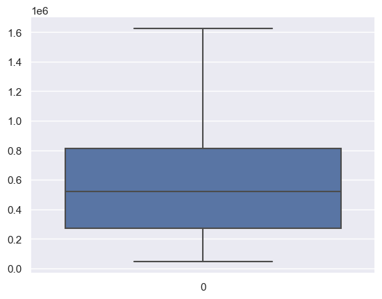

```
Box plot after removal of outliers in AMT_ANNUITY column
```

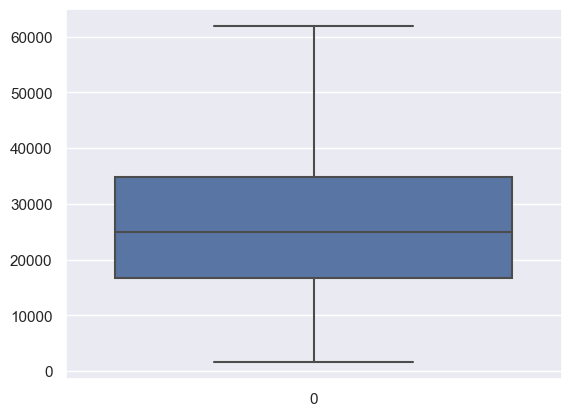

```
Box plot after removal of outliers in AMT_GOODS_PRICE column
```

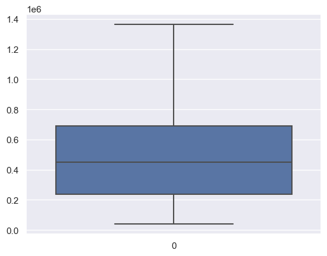

```
Box plot after removal of outliers in NAME_TYPE_SUITE column
```

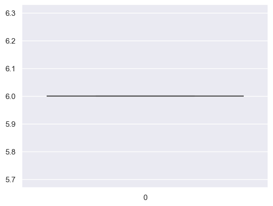

```
Box plot after removal of outliers in NAME_INCOME_TYPE column
```

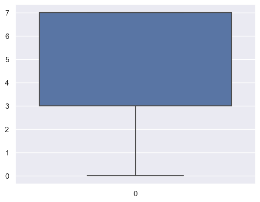

```
Box plot after removal of outliers in NAME_FAMILY_STATUS column
```

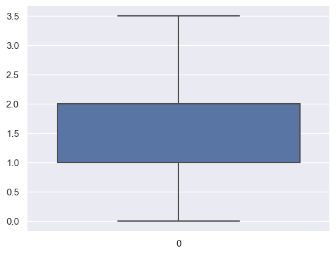

```
Box plot after removal of outliers in NAME_HOUSING_TYPE column
```

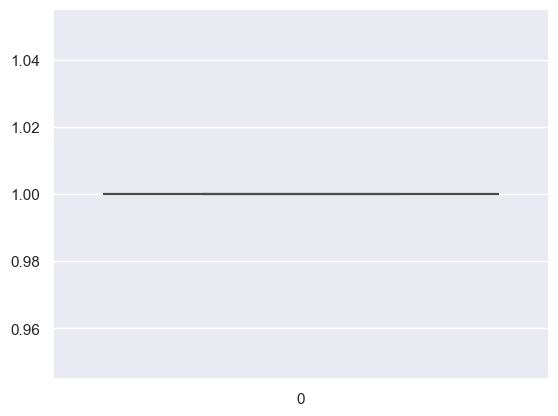

```
Box plot after removal of outliers in REGION_POPULATION_RELATIVE column
```

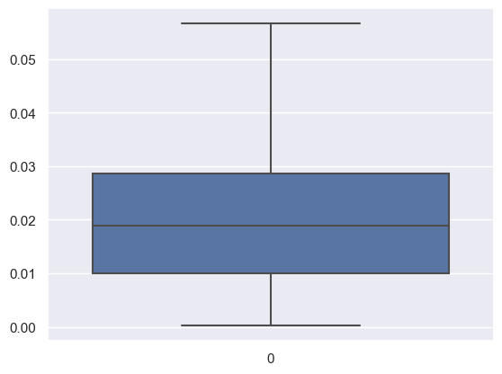

```
Box plot after removal of outliers in DAYS_BIRTH column
```

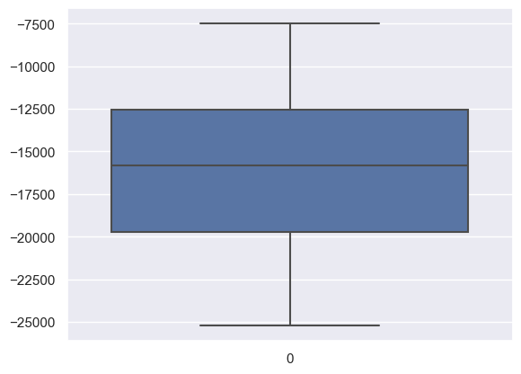

```
Box plot after removal of outliers in DAYS_EMPLOYED column
```

[15 more figures not shown]

```python
df=df_numeric
for col in df.columns:
                print(f'Box plot after removal of outliers in {col} column')
                sns.boxplot(df[col])
                plt.show()
```

```python
df_app_train_after_handling_outliers.shape
```

```
(263423, 40)
```

```python
df_app_train_after_handling_outliers.columns
```

```
Index(['SK_ID_CURR', 'CNT_CHILDREN', 'AMT_INCOME_TOTAL', 'AMT_CREDIT',
       'AMT_ANNUITY', 'AMT_GOODS_PRICE', 'NAME_TYPE_SUITE', 'NAME_INCOME_TYPE',
       'NAME_FAMILY_STATUS', 'NAME_HOUSING_TYPE', 'REGION_POPULATION_RELATIVE',
       'DAYS_BIRTH', 'DAYS_EMPLOYED', 'DAYS_REGISTRATION', 'DAYS_ID_PUBLISH',
       'OCCUPATION_TYPE', 'CNT_FAM_MEMBERS', 'REGION_RATING_CLIENT',
       'REGION_RATING_CLIENT_W_CITY', 'WEEKDAY_APPR_PROCESS_START',
       'HOUR_APPR_PROCESS_START', 'REG_REGION_NOT_LIVE_REGION',
       'REG_REGION_NOT_WORK_REGION', 'LIVE_REGION_NOT_WORK_REGION',
       'REG_CITY_NOT_LIVE_CITY', 'REG_CITY_NOT_WORK_CITY',
       'LIVE_CITY_NOT_WORK_CITY', 'ORGANIZATION_TYPE', 'EXT_SOURCE_2',
       'OBS_30_CNT_SOCIAL_CIRCLE', 'DEF_30_CNT_SOCIAL_CIRCLE',
       'OBS_60_CNT_SOCIAL_CIRCLE', 'DEF_60_CNT_SOCIAL_CIRCLE',
       'DAYS_LAST_PHONE_CHANGE', 'AMT_REQ_CREDIT_BUREAU_HOUR',
       'AMT_REQ_CREDIT_BUREAU_DAY', 'AMT_REQ_CREDIT_BUREAU_WEEK',
       'AMT_REQ_CREDIT_BUREAU_MON', 'AMT_REQ_CREDIT_BUREAU_QRT',
       'AMT_REQ_CREDIT_BUREAU_YEAR'],
      dtype='object')
```

```python
df_app_train_after_handling_outliers.head(5)
```

|  | SK_ID_CURR | CNT_CHILDREN | AMT_INCOME_TOTAL | AMT_CREDIT | AMT_ANNUITY | AMT_GOODS_PRICE | NAME_TYPE_SUITE | NAME_INCOME_TYPE | NAME_FAMILY_STATUS | NAME_HOUSING_TYPE | ... | DEF_30_CNT_SOCIAL_CIRCLE | OBS_60_CNT_SOCIAL_CIRCLE | DEF_60_CNT_SOCIAL_CIRCLE | DAYS_LAST_PHONE_CHANGE | AMT_REQ_CREDIT_BUREAU_HOUR | AMT_REQ_CREDIT_BUREAU_DAY | AMT_REQ_CREDIT_BUREAU_WEEK | AMT_REQ_CREDIT_BUREAU_MON | AMT_REQ_CREDIT_BUREAU_QRT | AMT_REQ_CREDIT_BUREAU_YEAR |
| --- | --- | --- | --- | --- | --- | --- | --- | --- | --- | --- | --- | --- | --- | --- | --- | --- | --- | --- | --- | --- | --- |
| 0 | 100002.0 | 0.0 | 202500.0 | 406597.5 | 24700.5 | 351000.0 | 6.0 | 7.0 | 3.0 | 1.0 | ... | 0.0 | 2.0 | 0.0 | -1134.0 | 0.0 | 0.0 | 0.0 | 0.0 | 0.0 | 1.0 |
| 1 | 100003.0 | 0.0 | 270000.0 | 1293502.5 | 35698.5 | 1129500.0 | 6.0 | 4.0 | 1.0 | 1.0 | ... | 0.0 | 1.0 | 0.0 | -828.0 | 0.0 | 0.0 | 0.0 | 0.0 | 0.0 | 0.0 |
| 2 | 100004.0 | 0.0 | 67500.0 | 135000.0 | 6750.0 | 135000.0 | 6.0 | 7.0 | 3.0 | 1.0 | ... | 0.0 | 0.0 | 0.0 | -815.0 | 0.0 | 0.0 | 0.0 | 0.0 | 0.0 | 0.0 |
| 4 | 100007.0 | 0.0 | 121500.0 | 513000.0 | 21865.5 | 513000.0 | 6.0 | 7.0 | 3.0 | 1.0 | ... | 0.0 | 0.0 | 0.0 | -1106.0 | 0.0 | 0.0 | 0.0 | 0.0 | 0.0 | 0.0 |
| 5 | 100008.0 | 0.0 | 99000.0 | 490495.5 | 27517.5 | 454500.0 | 6.0 | 4.0 | 1.0 | 1.0 | ... | 0.0 | 0.0 | 0.0 | -2536.0 | 0.0 | 0.0 | 0.0 | 0.0 | 0.0 | 1.0 |

5 rows × 40 columns

```python
type(df_app_train_after_handling_outliers)
```

```
pandas.core.frame.DataFrame
```

```python
df_app_train_after_handling_outliers.info()
```

```
<class 'pandas.core.frame.DataFrame'>
Index: 263423 entries, 0 to 307510
Data columns (total 40 columns):
 #   Column                       Non-Null Count   Dtype
---  ------                       --------------   -----
 0   SK_ID_CURR                   263423 non-null  float64
 1   CNT_CHILDREN                 263423 non-null  float64
 2   AMT_INCOME_TOTAL             263423 non-null  float64
 3   AMT_CREDIT                   263423 non-null  float64
 4   AMT_ANNUITY                  263423 non-null  float64
 5   AMT_GOODS_PRICE              263423 non-null  float64
 6   NAME_TYPE_SUITE              263423 non-null  float64
 7   NAME_INCOME_TYPE             263423 non-null  float64
 8   NAME_FAMILY_STATUS           263423 non-null  float64
 9   NAME_HOUSING_TYPE            263423 non-null  float64
```

[output cut: 32 more lines]

```python
df_app_train_after_handling_outliers.describe()
```

|  | SK_ID_CURR | CNT_CHILDREN | AMT_INCOME_TOTAL | AMT_CREDIT | AMT_ANNUITY | AMT_GOODS_PRICE | NAME_TYPE_SUITE | NAME_INCOME_TYPE | NAME_FAMILY_STATUS | NAME_HOUSING_TYPE | ... | DEF_30_CNT_SOCIAL_CIRCLE | OBS_60_CNT_SOCIAL_CIRCLE | DEF_60_CNT_SOCIAL_CIRCLE | DAYS_LAST_PHONE_CHANGE | AMT_REQ_CREDIT_BUREAU_HOUR | AMT_REQ_CREDIT_BUREAU_DAY | AMT_REQ_CREDIT_BUREAU_WEEK | AMT_REQ_CREDIT_BUREAU_MON | AMT_REQ_CREDIT_BUREAU_QRT | AMT_REQ_CREDIT_BUREAU_YEAR |
| --- | --- | --- | --- | --- | --- | --- | --- | --- | --- | --- | --- | --- | --- | --- | --- | --- | --- | --- | --- | --- | --- |
| count | 263423.000000 | 263423.000000 | 263423.000000 | 2.634230e+05 | 263423.000000 | 2.634230e+05 | 263423.0 | 263423.000000 | 263423.000000 | 263423.0 | ... | 263423.0 | 263423.000000 | 263423.0 | 263423.000000 | 263423.0 | 263423.0 | 263423.0 | 263423.0 | 263423.0 | 263423.000000 |
| mean | 278122.406115 | 0.413068 | 164911.911419 | 6.001633e+05 | 26922.694000 | 5.352616e+05 | 6.0 | 4.670017 | 1.384076 | 1.0 | ... | 0.0 | 1.215179 | 0.0 | -988.437855 | 0.0 | 0.0 | 0.0 | 0.0 | 0.0 | 1.892813 |
| std | 102818.879287 | 0.687329 | 73553.478081 | 3.824948e+05 | 13236.759183 | 3.403912e+05 | 0.0 | 2.540674 | 0.949931 | 0.0 | ... | 0.0 | 1.670837 | 0.0 | 832.337106 | 0.0 | 0.0 | 0.0 | 0.0 | 0.0 | 1.821363 |
| min | 100002.000000 | 0.000000 | 26100.000000 | 4.500000e+04 | 1615.500000 | 4.050000e+04 | 6.0 | 0.000000 | 0.000000 | 1.0 | ... | 0.0 | 0.000000 | 0.0 | -3578.500000 | 0.0 | 0.0 | 0.0 | 0.0 | 0.0 | 0.000000 |
| 25% | 188975.500000 | 0.000000 | 112500.000000 | 2.730240e+05 | 16681.500000 | 2.385000e+05 | 6.0 | 3.000000 | 1.000000 | 1.0 | ... | 0.0 | 0.000000 | 0.0 | -1603.000000 | 0.0 | 0.0 | 0.0 | 0.0 | 0.0 | 0.000000 |
| 50% | 278016.000000 | 0.000000 | 157500.000000 | 5.212800e+05 | 25033.500000 | 4.500000e+05 | 6.0 | 7.000000 | 1.000000 | 1.0 | ... | 0.0 | 0.000000 | 0.0 | -798.000000 | 0.0 | 0.0 | 0.0 | 0.0 | 0.0 | 1.000000 |
| 75% | 367195.500000 | 1.000000 | 202500.000000 | 8.140410e+05 | 34780.500000 | 6.885000e+05 | 6.0 | 7.000000 | 2.000000 | 1.0 | ... | 0.0 | 2.000000 | 0.0 | -286.000000 | 0.0 | 0.0 | 0.0 | 0.0 | 0.0 | 3.000000 |
| max | 456255.000000 | 2.500000 | 337500.000000 | 1.625566e+06 | 61929.000000 | 1.363500e+06 | 6.0 | 7.000000 | 3.500000 | 1.0 | ... | 0.0 | 5.000000 | 0.0 | 0.000000 | 0.0 | 0.0 | 0.0 | 0.0 | 0.0 | 7.500000 |

8 rows × 40 columns

# Applying PCA on columns after removing nans

#### PCA Analysis for reducing the dimension

#### The principal components are basically the linear combinations of the original variables weighted by their contribution

#### to explain the variance in a particular orthogonal dimension.

```python
df_pca_prep = df_app_train_after_handling_outliers.copy()
```

```python
df_pca_prep.head(5)
```

|  | SK_ID_CURR | CNT_CHILDREN | AMT_INCOME_TOTAL | AMT_CREDIT | AMT_ANNUITY | AMT_GOODS_PRICE | NAME_TYPE_SUITE | NAME_INCOME_TYPE | NAME_FAMILY_STATUS | NAME_HOUSING_TYPE | ... | DEF_30_CNT_SOCIAL_CIRCLE | OBS_60_CNT_SOCIAL_CIRCLE | DEF_60_CNT_SOCIAL_CIRCLE | DAYS_LAST_PHONE_CHANGE | AMT_REQ_CREDIT_BUREAU_HOUR | AMT_REQ_CREDIT_BUREAU_DAY | AMT_REQ_CREDIT_BUREAU_WEEK | AMT_REQ_CREDIT_BUREAU_MON | AMT_REQ_CREDIT_BUREAU_QRT | AMT_REQ_CREDIT_BUREAU_YEAR |
| --- | --- | --- | --- | --- | --- | --- | --- | --- | --- | --- | --- | --- | --- | --- | --- | --- | --- | --- | --- | --- | --- |
| 0 | 100002.0 | 0.0 | 202500.0 | 406597.5 | 24700.5 | 351000.0 | 6.0 | 7.0 | 3.0 | 1.0 | ... | 0.0 | 2.0 | 0.0 | -1134.0 | 0.0 | 0.0 | 0.0 | 0.0 | 0.0 | 1.0 |
| 1 | 100003.0 | 0.0 | 270000.0 | 1293502.5 | 35698.5 | 1129500.0 | 6.0 | 4.0 | 1.0 | 1.0 | ... | 0.0 | 1.0 | 0.0 | -828.0 | 0.0 | 0.0 | 0.0 | 0.0 | 0.0 | 0.0 |
| 2 | 100004.0 | 0.0 | 67500.0 | 135000.0 | 6750.0 | 135000.0 | 6.0 | 7.0 | 3.0 | 1.0 | ... | 0.0 | 0.0 | 0.0 | -815.0 | 0.0 | 0.0 | 0.0 | 0.0 | 0.0 | 0.0 |
| 4 | 100007.0 | 0.0 | 121500.0 | 513000.0 | 21865.5 | 513000.0 | 6.0 | 7.0 | 3.0 | 1.0 | ... | 0.0 | 0.0 | 0.0 | -1106.0 | 0.0 | 0.0 | 0.0 | 0.0 | 0.0 | 0.0 |
| 5 | 100008.0 | 0.0 | 99000.0 | 490495.5 | 27517.5 | 454500.0 | 6.0 | 4.0 | 1.0 | 1.0 | ... | 0.0 | 0.0 | 0.0 | -2536.0 | 0.0 | 0.0 | 0.0 | 0.0 | 0.0 | 1.0 |

5 rows × 40 columns

```python
df_pca_prep.describe()
```

|  | SK_ID_CURR | CNT_CHILDREN | AMT_INCOME_TOTAL | AMT_CREDIT | AMT_ANNUITY | AMT_GOODS_PRICE | NAME_TYPE_SUITE | NAME_INCOME_TYPE | NAME_FAMILY_STATUS | NAME_HOUSING_TYPE | ... | DEF_30_CNT_SOCIAL_CIRCLE | OBS_60_CNT_SOCIAL_CIRCLE | DEF_60_CNT_SOCIAL_CIRCLE | DAYS_LAST_PHONE_CHANGE | AMT_REQ_CREDIT_BUREAU_HOUR | AMT_REQ_CREDIT_BUREAU_DAY | AMT_REQ_CREDIT_BUREAU_WEEK | AMT_REQ_CREDIT_BUREAU_MON | AMT_REQ_CREDIT_BUREAU_QRT | AMT_REQ_CREDIT_BUREAU_YEAR |
| --- | --- | --- | --- | --- | --- | --- | --- | --- | --- | --- | --- | --- | --- | --- | --- | --- | --- | --- | --- | --- | --- |
| count | 263423.000000 | 263423.000000 | 263423.000000 | 2.634230e+05 | 263423.000000 | 2.634230e+05 | 263423.0 | 263423.000000 | 263423.000000 | 263423.0 | ... | 263423.0 | 263423.000000 | 263423.0 | 263423.000000 | 263423.0 | 263423.0 | 263423.0 | 263423.0 | 263423.0 | 263423.000000 |
| mean | 278122.406115 | 0.413068 | 164911.911419 | 6.001633e+05 | 26922.694000 | 5.352616e+05 | 6.0 | 4.670017 | 1.384076 | 1.0 | ... | 0.0 | 1.215179 | 0.0 | -988.437855 | 0.0 | 0.0 | 0.0 | 0.0 | 0.0 | 1.892813 |
| std | 102818.879287 | 0.687329 | 73553.478081 | 3.824948e+05 | 13236.759183 | 3.403912e+05 | 0.0 | 2.540674 | 0.949931 | 0.0 | ... | 0.0 | 1.670837 | 0.0 | 832.337106 | 0.0 | 0.0 | 0.0 | 0.0 | 0.0 | 1.821363 |
| min | 100002.000000 | 0.000000 | 26100.000000 | 4.500000e+04 | 1615.500000 | 4.050000e+04 | 6.0 | 0.000000 | 0.000000 | 1.0 | ... | 0.0 | 0.000000 | 0.0 | -3578.500000 | 0.0 | 0.0 | 0.0 | 0.0 | 0.0 | 0.000000 |
| 25% | 188975.500000 | 0.000000 | 112500.000000 | 2.730240e+05 | 16681.500000 | 2.385000e+05 | 6.0 | 3.000000 | 1.000000 | 1.0 | ... | 0.0 | 0.000000 | 0.0 | -1603.000000 | 0.0 | 0.0 | 0.0 | 0.0 | 0.0 | 0.000000 |
| 50% | 278016.000000 | 0.000000 | 157500.000000 | 5.212800e+05 | 25033.500000 | 4.500000e+05 | 6.0 | 7.000000 | 1.000000 | 1.0 | ... | 0.0 | 0.000000 | 0.0 | -798.000000 | 0.0 | 0.0 | 0.0 | 0.0 | 0.0 | 1.000000 |
| 75% | 367195.500000 | 1.000000 | 202500.000000 | 8.140410e+05 | 34780.500000 | 6.885000e+05 | 6.0 | 7.000000 | 2.000000 | 1.0 | ... | 0.0 | 2.000000 | 0.0 | -286.000000 | 0.0 | 0.0 | 0.0 | 0.0 | 0.0 | 3.000000 |
| max | 456255.000000 | 2.500000 | 337500.000000 | 1.625566e+06 | 61929.000000 | 1.363500e+06 | 6.0 | 7.000000 | 3.500000 | 1.0 | ... | 0.0 | 5.000000 | 0.0 | 0.000000 | 0.0 | 0.0 | 0.0 | 0.0 | 0.0 | 7.500000 |

8 rows × 40 columns

```python
list(df_pca_prep.columns)
```

```
['SK_ID_CURR',
 'CNT_CHILDREN',
 'AMT_INCOME_TOTAL',
 'AMT_CREDIT',
 'AMT_ANNUITY',
 'AMT_GOODS_PRICE',
 'NAME_TYPE_SUITE',
 'NAME_INCOME_TYPE',
 'NAME_FAMILY_STATUS',
 'NAME_HOUSING_TYPE',
 'REGION_POPULATION_RELATIVE',
 'DAYS_BIRTH',
 'DAYS_EMPLOYED',
 'DAYS_REGISTRATION',
 'DAYS_ID_PUBLISH',
 'OCCUPATION_TYPE',
 'CNT_FAM_MEMBERS',
 'REGION_RATING_CLIENT',
 'REGION_RATING_CLIENT_W_CITY',
 'WEEKDAY_APPR_PROCESS_START',
 'HOUR_APPR_PROCESS_START',
 'REG_REGION_NOT_LIVE_REGION',
 'REG_REGION_NOT_WORK_REGION',
 'LIVE_REGION_NOT_WORK_REGION',
 'REG_CITY_NOT_LIVE_CITY',
 'REG_CITY_NOT_WORK_CITY',
 'LIVE_CITY_NOT_WORK_CITY',
 'ORGANIZATION_TYPE',
 'EXT_SOURCE_2',
 'OBS_30_CNT_SOCIAL_CIRCLE',
 'DEF_30_CNT_SOCIAL_CIRCLE',
 'OBS_60_CNT_SOCIAL_CIRCLE',
 'DEF_60_CNT_SOCIAL_CIRCLE',
 'DAYS_LAST_PHONE_CHANGE',
 'AMT_REQ_CREDIT_BUREAU_HOUR',
 'AMT_REQ_CREDIT_BUREAU_DAY',
 'AMT_REQ_CREDIT_BUREAU_WEEK',
 'AMT_REQ_CREDIT_BUREAU_MON',
 'AMT_REQ_CREDIT_BUREAU_QRT',
 'AMT_REQ_CREDIT_BUREAU_YEAR']
```

```python
## CHECK ALL COLUMNS WITH NEGATIVE VALUES

df_columns_negative_values = []
for col in df_pca_prep.loc[:, df_pca_prep.columns!='AGE_IN_YEARS'].columns:
    if (df_pca_prep[col] < 0).any():
        df_columns_negative_values.append(col)
```

```python
df_columns_negative_values
```

```
['DAYS_BIRTH',
 'DAYS_EMPLOYED',
 'DAYS_REGISTRATION',
 'DAYS_ID_PUBLISH',
 'DAYS_LAST_PHONE_CHANGE']
```

### CREATE NEW COLUMNS IN YEARS/ FEATURES IMPROVED

```python
df_pca_prep["AGE_IN_YEARS"]= (-(df_pca_prep["DAYS_BIRTH"])/365)
```

```python
df_pca_prep["EMPLOYMENT_YEARS"]= (-(df_pca_prep["DAYS_EMPLOYED"])/365)
```

```python
df_pca_prep["REGISTRATION_YEARS"]= (-(df_pca_prep["DAYS_REGISTRATION"])/365)
```

```python
df_pca_prep["ID_PUBLISH_YEARS"]= (-(df_pca_prep["DAYS_ID_PUBLISH"])/365)
```

```python
df_pca_prep["YEARS_PHN_CHANGE"]= (-(df_pca_prep["DAYS_LAST_PHONE_CHANGE"])/365)
```

### DROP DAYS COLUMNS WITH NEGATIVE VALUES

```python
df_pca_prep.drop('DAYS_BIRTH', axis=1, inplace=True)
df_pca_prep.drop('DAYS_EMPLOYED', axis=1, inplace=True)
df_pca_prep.drop('DAYS_REGISTRATION', axis=1, inplace=True)
df_pca_prep.drop('DAYS_ID_PUBLISH', axis=1, inplace=True)
df_pca_prep.drop('DAYS_LAST_PHONE_CHANGE', axis=1, inplace=True)
```

### PCA -Principal component analysis

```python
df_PCA= df_pca_prep.copy()

# Import the PCA function from sklearn
from sklearn.decomposition import PCA

# Select the number of principal components we will return
num_components = 5

# Create the PCA model
pca = PCA(n_components=num_components)

# Fit the model with the standardised data
pca.fit(df_PCA) ###pca used to shadow the no. of var
```

```
PCA(n_components=5)
```

```python
pca.explained_variance_
```

```
array([2.61348547e+11, 1.05718905e+10, 4.50178732e+09, 1.84487527e+09,
       5.83903922e+07])
```

```python
pca.explained_variance_ratio_.cumsum() ## gives cumulative sum of variance covered by each factor
```

```
array([0.93900327, 0.97698718, 0.99316172, 0.99979021, 1.        ])
```

```
[9.39003275e-01 3.79839104e-02 1.61745420e-02 6.62848116e-03
 2.09791752e-04]
```

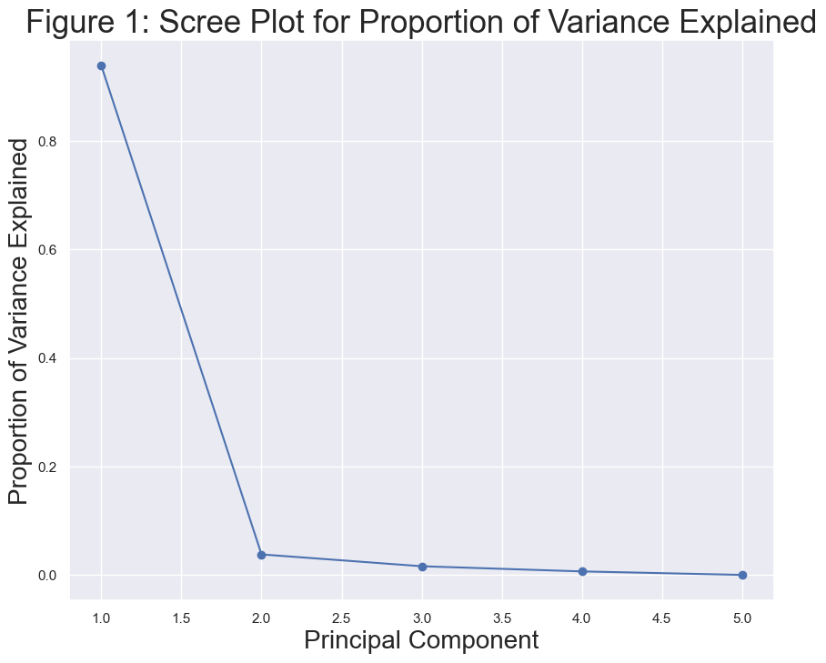

```python
### The principal components are basically the linear combinations of the original variables weighted by their contribution to explain the variance in a particular orthogonal dimension.Here we choose five principal components

pca.components_ #### these are eigen vectors or principal components

eigenvalues = pca.explained_variance_   ##variance of each feature #### these are eigen values
prop_var = eigenvalues / np.sum(eigenvalues) ## proportion of variance
print(prop_var)

plt.figure(figsize=(10,8))
plt.plot(np.arange(1, len(prop_var)+1),
                   prop_var, marker='o')
plt.xlabel('Principal Component',
           size = 20)
plt.ylabel('Proportion of Variance Explained',
           size = 20)
plt.title('Figure 1: Scree Plot for Proportion of Variance Explained',
          size = 25)
plt.grid(True)

### According to elbow rule we will retain only first two components
```

```python
### Presentation of PCA results

import pylab as pl
from sklearn.decomposition import PCA
from sklearn import preprocessing

pca_com = pca.components_ ## these are eigen vectors or principal components ## gives weight of each of the feature column
data_for_PCA = df_PCA
X_pca = pca.fit_transform(data_for_PCA)

df_PCA_columns= df_PCA.columns
pca_exp_var = pca.explained_variance_
pca_inv= pca.inverse_transform(X_pca)## getting inverse transform of PCA

pca_feature_map = {}
for pca_index, pca_val in enumerate(pca_com):
    pca_feature_map[f'PC{pca_index + 1}'] = {feat: eigen_weight for feat, eigen_weight in zip(df_PCA_columns, pca_val)}

pd.DataFrame.from_dict(pca_feature_map,orient='index') ### the results for components in terms of weight of each feature
```

|  | SK_ID_CURR | CNT_CHILDREN | AMT_INCOME_TOTAL | AMT_CREDIT | AMT_ANNUITY | AMT_GOODS_PRICE | NAME_TYPE_SUITE | NAME_INCOME_TYPE | NAME_FAMILY_STATUS | NAME_HOUSING_TYPE | ... | AMT_REQ_CREDIT_BUREAU_DAY | AMT_REQ_CREDIT_BUREAU_WEEK | AMT_REQ_CREDIT_BUREAU_MON | AMT_REQ_CREDIT_BUREAU_QRT | AMT_REQ_CREDIT_BUREAU_YEAR | AGE_IN_YEARS | EMPLOYMENT_YEARS | REGISTRATION_YEARS | ID_PUBLISH_YEARS | YEARS_PHN_CHANGE |
| --- | --- | --- | --- | --- | --- | --- | --- | --- | --- | --- | --- | --- | --- | --- | --- | --- | --- | --- | --- | --- | --- |
| PC1 | -0.000233 | 1.007813e-09 | 0.059698 | 0.746076 | 0.020668 | 0.662857 | 0.0 | -3.313774e-07 | -1.945486e-07 | 0.0 | ... | 0.0 | 0.0 | 0.0 | 0.0 | -1.579877e-07 | 1.064274e-06 | 1.675596e-06 | -2.193260e-07 | -1.297464e-08 | 3.390334e-07 |
| PC2 | 0.999985 | -6.508333e-09 | 0.005458 | -0.000350 | 0.000242 | 0.000247 | -0.0 | -8.352452e-08 | 1.859180e-08 | -0.0 | ... | -0.0 | -0.0 | -0.0 | -0.0 | 8.761520e-08 | 2.640469e-07 | -6.235086e-08 | 6.838982e-08 | -1.510453e-08 | 2.074819e-08 |
| PC3 | -0.005468 | 3.425980e-07 | 0.997259 | -0.061875 | 0.034127 | -0.021237 | -0.0 | -3.301352e-06 | 1.338055e-07 | -0.0 | ... | -0.0 | -0.0 | -0.0 | -0.0 | 2.174319e-06 | -2.079571e-05 | 1.511658e-05 | -1.173463e-05 | -2.525002e-06 | 1.016300e-06 |
| PC4 | -0.000280 | -3.899720e-07 | -0.025343 | -0.662897 | 0.004304 | 0.748269 | 0.0 | 1.903761e-07 | -3.272243e-07 | 0.0 | ... | 0.0 | 0.0 | 0.0 | 0.0 | -5.510258e-07 | -7.906565e-08 | -4.293612e-07 | -1.287160e-06 | 1.436109e-06 | 1.313495e-06 |
| PC5 | -0.000049 | 2.900922e-06 | -0.035188 | -0.010464 | 0.999194 | -0.016208 | 0.0 | -1.574578e-07 | -4.704289e-06 | 0.0 | ... | 0.0 | 0.0 | 0.0 | 0.0 | 5.336644e-06 | -9.520038e-05 | 1.728771e-05 | -3.928743e-05 | -1.047084e-05 | -1.815229e-07 |

5 rows × 40 columns

```python
# Get the loadings of each feature on the principal components
loadings = pca.components_

# Threshold for non-zero loadings (you can adjust this based on your criteria)
threshold = 0.002

# Get features whose loadings are not zero based on the threshold
non_zero_features = df_PCA.columns[np.any(np.abs(loadings) > threshold, axis=0)]

# Display the features with non-zero loadings
print("Features with non-zero loadings after PCA:")
print(non_zero_features)
```

```
Features with non-zero loadings after PCA:
Index(['SK_ID_CURR', 'AMT_INCOME_TOTAL', 'AMT_CREDIT', 'AMT_ANNUITY',
       'AMT_GOODS_PRICE'],
      dtype='object')
```

## Selecting features after PCA

```python
### Reference:Hands-On Machine Learning with Scikit-L
```

```python
loadings_first_pc = pca.components_[0]
#print("Loadings for the first principal component:")
#print(loadings_first_pc)
threshold = 0
###threshold is a parameter that can be adjusted based on criteria for considering a loading as non-zero.

non_zero_features_first_pc = df_PCA.columns[np.abs(loadings_first_pc) > threshold]
print("Non-zero features for the first principal component:")
print(non_zero_features_first_pc)
```

```
Non-zero features for the first principal component:
Index(['SK_ID_CURR', 'CNT_CHILDREN', 'AMT_INCOME_TOTAL', 'AMT_CREDIT',
       'AMT_ANNUITY', 'AMT_GOODS_PRICE', 'NAME_TYPE_SUITE', 'NAME_INCOME_TYPE',
       'NAME_FAMILY_STATUS', 'REGION_POPULATION_RELATIVE', 'OCCUPATION_TYPE',
       'CNT_FAM_MEMBERS', 'WEEKDAY_APPR_PROCESS_START',
       'HOUR_APPR_PROCESS_START', 'ORGANIZATION_TYPE', 'EXT_SOURCE_2',
       'OBS_30_CNT_SOCIAL_CIRCLE', 'OBS_60_CNT_SOCIAL_CIRCLE',
       'AMT_REQ_CREDIT_BUREAU_YEAR', 'AGE_IN_YEARS', 'EMPLOYMENT_YEARS',
       'REGISTRATION_YEARS', 'ID_PUBLISH_YEARS', 'YEARS_PHN_CHANGE'],
      dtype='object')
```

### PC1 gives the best linear combination here

```python
list(df_PCA.columns)
```

```
['SK_ID_CURR',
 'CNT_CHILDREN',
 'AMT_INCOME_TOTAL',
 'AMT_CREDIT',
 'AMT_ANNUITY',
 'AMT_GOODS_PRICE',
 'NAME_TYPE_SUITE',
 'NAME_INCOME_TYPE',
 'NAME_FAMILY_STATUS',
 'NAME_HOUSING_TYPE',
 'REGION_POPULATION_RELATIVE',
 'OCCUPATION_TYPE',
 'CNT_FAM_MEMBERS',
 'REGION_RATING_CLIENT',
 'REGION_RATING_CLIENT_W_CITY',
 'WEEKDAY_APPR_PROCESS_START',
 'HOUR_APPR_PROCESS_START',
 'REG_REGION_NOT_LIVE_REGION',
 'REG_REGION_NOT_WORK_REGION',
 'LIVE_REGION_NOT_WORK_REGION',
 'REG_CITY_NOT_LIVE_CITY',
 'REG_CITY_NOT_WORK_CITY',
 'LIVE_CITY_NOT_WORK_CITY',
 'ORGANIZATION_TYPE',
 'EXT_SOURCE_2',
 'OBS_30_CNT_SOCIAL_CIRCLE',
 'DEF_30_CNT_SOCIAL_CIRCLE',
 'OBS_60_CNT_SOCIAL_CIRCLE',
 'DEF_60_CNT_SOCIAL_CIRCLE',
 'AMT_REQ_CREDIT_BUREAU_HOUR',
 'AMT_REQ_CREDIT_BUREAU_DAY',
 'AMT_REQ_CREDIT_BUREAU_WEEK',
 'AMT_REQ_CREDIT_BUREAU_MON',
 'AMT_REQ_CREDIT_BUREAU_QRT',
 'AMT_REQ_CREDIT_BUREAU_YEAR',
 'AGE_IN_YEARS',
 'EMPLOYMENT_YEARS',
 'REGISTRATION_YEARS',
 'ID_PUBLISH_YEARS',
 'YEARS_PHN_CHANGE']
```

### Creating a merged Dataframe to add Target and Flags

```python
df_target=df_flags['TARGET']
```

```python
df_combined=pd.merge(df_PCA,df_target,left_index=True, right_index=True, how='inner')
```

```python
df_combined.info()
```

```
<class 'pandas.core.frame.DataFrame'>
Index: 263423 entries, 0 to 307510
Data columns (total 41 columns):
 #   Column                       Non-Null Count   Dtype
---  ------                       --------------   -----
 0   SK_ID_CURR                   263423 non-null  float64
 1   CNT_CHILDREN                 263423 non-null  float64
 2   AMT_INCOME_TOTAL             263423 non-null  float64
 3   AMT_CREDIT                   263423 non-null  float64
 4   AMT_ANNUITY                  263423 non-null  float64
 5   AMT_GOODS_PRICE              263423 non-null  float64
 6   NAME_TYPE_SUITE              263423 non-null  float64
 7   NAME_INCOME_TYPE             263423 non-null  float64
 8   NAME_FAMILY_STATUS           263423 non-null  float64
 9   NAME_HOUSING_TYPE            263423 non-null  float64
```

[output cut: 33 more lines]

```python
df_selected_after_pca = df_combined.copy()
```

```python
df_selected_after_pca.head(5)
```

|  | SK_ID_CURR | CNT_CHILDREN | AMT_INCOME_TOTAL | AMT_CREDIT | AMT_ANNUITY | AMT_GOODS_PRICE | NAME_TYPE_SUITE | NAME_INCOME_TYPE | NAME_FAMILY_STATUS | NAME_HOUSING_TYPE | ... | AMT_REQ_CREDIT_BUREAU_WEEK | AMT_REQ_CREDIT_BUREAU_MON | AMT_REQ_CREDIT_BUREAU_QRT | AMT_REQ_CREDIT_BUREAU_YEAR | AGE_IN_YEARS | EMPLOYMENT_YEARS | REGISTRATION_YEARS | ID_PUBLISH_YEARS | YEARS_PHN_CHANGE | TARGET |
| --- | --- | --- | --- | --- | --- | --- | --- | --- | --- | --- | --- | --- | --- | --- | --- | --- | --- | --- | --- | --- | --- |
| 0 | 100002.0 | 0.0 | 202500.0 | 406597.5 | 24700.5 | 351000.0 | 6.0 | 7.0 | 3.0 | 1.0 | ... | 0.0 | 0.0 | 0.0 | 1.0 | 25.920548 | 1.745205 | 9.994521 | 5.808219 | 3.106849 | 1 |
| 1 | 100003.0 | 0.0 | 270000.0 | 1293502.5 | 35698.5 | 1129500.0 | 6.0 | 4.0 | 1.0 | 1.0 | ... | 0.0 | 0.0 | 0.0 | 0.0 | 45.931507 | 3.254795 | 3.249315 | 0.797260 | 2.268493 | 0 |
| 2 | 100004.0 | 0.0 | 67500.0 | 135000.0 | 6750.0 | 135000.0 | 6.0 | 7.0 | 3.0 | 1.0 | ... | 0.0 | 0.0 | 0.0 | 0.0 | 52.180822 | 0.616438 | 11.671233 | 6.934247 | 2.232877 | 0 |
| 4 | 100007.0 | 0.0 | 121500.0 | 513000.0 | 21865.5 | 513000.0 | 6.0 | 7.0 | 3.0 | 1.0 | ... | 0.0 | 0.0 | 0.0 | 0.0 | 54.608219 | 8.323288 | 11.810959 | 9.473973 | 3.030137 | 0 |
| 5 | 100008.0 | 0.0 | 99000.0 | 490495.5 | 27517.5 | 454500.0 | 6.0 | 4.0 | 1.0 | 1.0 | ... | 0.0 | 0.0 | 0.0 | 1.0 | 46.413699 | 4.350685 | 13.616438 | 1.306849 | 6.947945 | 0 |

5 rows × 41 columns

### FEATURE ENGINEERING

```python
df_selected_after_pca['CREDIT_TO_INCOME_RATIO']= 100*( df_selected_after_pca['AMT_CREDIT']/df_selected_after_pca['AMT_INCOME_TOTAL'])
```

```python
df_selected_after_pca['CREDIT_TO_INCOME_RATIO']
```

```
0         200.788889
1         479.075000
2         200.000000
4         422.222222
5         495.450000
             ...
307503    307.120000
307505    200.000000
307508    442.917647
307509    216.436842
307510    428.571429
Name: CREDIT_TO_INCOME_RATIO, Length: 263423, dtype: float64
```

```python
df_train_new =df_selected_after_pca.copy()
```

### Finding correlation between columns

```python
fig = plt.figure(figsize=(38,38), dpi = 480)
sns.heatmap(df_train_new.corr(), annot = True, fmt = '.2f')
```

[figure not shown]

### From this heat map

#### 'AMT_GOODS_PRICE' ,'AMT_ANNUITY','AMT_CREDIT' are highly correlated

#### 'CNT_CHILDREN' and 'CNT_FAMILY_MEMBERS' are highly correlated

### Columns: 'AMT_GOODS_PRICE' ,'AMT_ANNUITY','CNT_CHILDREN' can be dropped

```python
df_train_new.drop('AMT_GOODS_PRICE', axis=1, inplace=True)
df_train_new.drop('AMT_ANNUITY', axis=1, inplace=True)
df_train_new.drop('CNT_CHILDREN', axis=1, inplace=True)
```

```python
## COLUMNS THAT ARE NOT CONTRIBUTING ARE DROPPED
```

```python
df_train_new.drop('AMT_REQ_CREDIT_BUREAU_WEEK', axis=1, inplace=True)
df_train_new.drop('AMT_REQ_CREDIT_BUREAU_DAY', axis=1, inplace=True)
df_train_new.drop('AMT_REQ_CREDIT_BUREAU_HOUR', axis=1, inplace=True)
df_train_new.drop('AMT_REQ_CREDIT_BUREAU_MON', axis=1, inplace=True)
df_train_new.drop('AMT_REQ_CREDIT_BUREAU_QRT', axis=1, inplace=True)
df_train_new.drop('REG_CITY_NOT_LIVE_CITY', axis=1, inplace=True)
df_train_new.drop('REG_CITY_NOT_WORK_CITY', axis=1, inplace=True)
df_train_new.drop('REG_REGION_NOT_WORK_REGION', axis=1, inplace=True)
df_train_new.drop('REG_REGION_NOT_LIVE_REGION', axis=1, inplace=True)
```

```python
df_train_new.shape
```

```
(263423, 30)
```

```python
df_train_new.columns
```

```
Index(['SK_ID_CURR', 'AMT_INCOME_TOTAL', 'AMT_CREDIT', 'NAME_TYPE_SUITE',
       'NAME_INCOME_TYPE', 'NAME_FAMILY_STATUS', 'NAME_HOUSING_TYPE',
       'REGION_POPULATION_RELATIVE', 'OCCUPATION_TYPE', 'CNT_FAM_MEMBERS',
       'REGION_RATING_CLIENT', 'REGION_RATING_CLIENT_W_CITY',
       'WEEKDAY_APPR_PROCESS_START', 'HOUR_APPR_PROCESS_START',
       'LIVE_REGION_NOT_WORK_REGION', 'LIVE_CITY_NOT_WORK_CITY',
       'ORGANIZATION_TYPE', 'EXT_SOURCE_2', 'OBS_30_CNT_SOCIAL_CIRCLE',
       'DEF_30_CNT_SOCIAL_CIRCLE', 'OBS_60_CNT_SOCIAL_CIRCLE',
       'DEF_60_CNT_SOCIAL_CIRCLE', 'AMT_REQ_CREDIT_BUREAU_YEAR',
       'AGE_IN_YEARS', 'EMPLOYMENT_YEARS', 'REGISTRATION_YEARS',
       'ID_PUBLISH_YEARS', 'YEARS_PHN_CHANGE', 'TARGET',
       'CREDIT_TO_INCOME_RATIO'],
      dtype='object')
```

### RANDOM FOREST

```python
from sklearn.metrics import roc_auc_score, roc_curve
```

```python
X=df_train_new.drop(columns=['TARGET'])

y=df_train_new['TARGET']
```

```python
y.value_counts()
```

```
TARGET
0    243016
1     20407
Name: count, dtype: int64
```

```python
## Dataset is heavily biased ,there are approx. 12x more rejections than acceptance
```

```python
X_train, X_test, y_train, y_test = train_test_split(X, y, test_size=0.2, random_state=42)
```

```python
model_rf_yes_no = RandomForestClassifier(random_state=42)

model_rf_yes_no.fit(X_train, y_train)
```

```
RandomForestClassifier(random_state=42)
```

```python
y_pred = model_rf_yes_no.predict(X_test)
```

```python
accuracy = accuracy_score(y_test, y_pred)
```

```python
print(f"Accuracy: {accuracy}")
```

```
Accuracy: 0.9216475277593242
```

```python
 conf_matrix = confusion_matrix(y_test, y_pred)
```

```python
print(conf_matrix)
```

```
[[48556     1]
 [ 4127     1]]
```

```python
f1 = f1_score(y_test, y_pred)
```

```python
f1
```

```
0.0004842615012106538
```

```python
from sklearn.metrics import precision_score
```

```python
precision_of_model = precision_score(y_test, y_pred)
```

```python
print(precision_of_model)
```

```
0.5
```

```python
# Predict probabilities for the positive class
y_probs = model_rf_yes_no.predict_proba(X_test)[:, 1]
```

```python
from sklearn.metrics import roc_auc_score, roc_curve
```

```python
# Calculate AUC-ROC score
auc_roc_score = roc_auc_score(y_test, y_probs)
print(f"AUC-ROC Score: {auc_roc_score}")
```

```
AUC-ROC Score: 0.6595307033865578
```

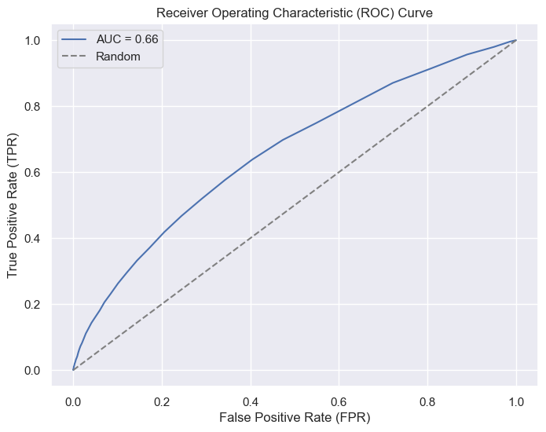

```python
# Calculate ROC curve
fpr, tpr, thresholds = roc_curve(y_test, y_probs)

# Plot ROC curve
plt.figure(figsize=(8, 6))
plt.plot(fpr, tpr, label=f'AUC = {auc_roc_score:.2f}')
plt.plot([0, 1], [0, 1], linestyle='--', color='gray', label='Random')
plt.title('Receiver Operating Characteristic (ROC) Curve')
plt.xlabel('False Positive Rate (FPR)')
plt.ylabel('True Positive Rate (TPR)')
plt.legend()
plt.show()
```

### LOGISTIC REGRESSION MODEL

```python
from sklearn.model_selection import train_test_split
from sklearn.model_selection import GridSearchCV
```

```python
scaler = StandardScaler()
X_train = scaler.fit_transform(X_train)
```

```python
# Create a logistic regression model
logreg_model_yes_no = LogisticRegression()
```

#### Grid Search is a hyperparameter tuning technique used to identify the ideal parameters that can improve the learning process and

#### accuracy of a machine learning model.

#### Hyperparameters are the configuration settings used to tune the model performance. They are not learned from the data but are set

#### beforehand and influence the learning process.

#### In essence, Grid Search is an exhaustive search method that works by defining a grid of hyperparameters and evaluating the model’s

#### performance for each point on the grid. You can think of this process as a brute-force method to estimate hyperparameters.

### THE PROCESS

#### Grid Search operates by constructing a grid of hyperparameter values and evaluating the model’s performance for each combination in this

#### hyperparameter space. This is accomplished through cross-validation, typically k-fold cross-validation, where the data is split into k subsets,

#### and the holdout method is repeated k times.

#### For every possible combination of hyperparameters on the grid, the following steps are executed:

#### 1. Set the model with the specific combination of hyperparameters.

#### 2. Perform k-fold cross-validation.

#### 3. Calculate the average result.

#### The combination of hyperparameters that yields the best average result is selected as the optimal solution.

##### Reference: https://towardsdatascience.com/grid-search-for-model-tuning-3319b259367e

```python
param_grid = {
    'C': np.logspace(-6.0, 6.0, 20),
    'class_weight': [None, 'balanced'],
    'penalty': ['l1', 'l2']
}
```

```python
# Grid search with cross-validation
grid_search = GridSearchCV(logreg_model_yes_no, param_grid, cv=5, scoring='roc_auc', verbose=1, n_jobs=-1)
```

```python
grid_search.fit(X_train, y_train)
```

```
Fitting 5 folds for each of 80 candidates, totalling 400 fits
```

[output not shown]

```
GridSearchCV(cv=5, estimator=LogisticRegression(), n_jobs=-1,
             param_grid={'C': array([1.00000000e-06, 4.28133240e-06, 1.83298071e-05, 7.84759970e-05,
       3.35981829e-04, 1.43844989e-03, 6.15848211e-03, 2.63665090e-02,
       1.12883789e-01, 4.83293024e-01, 2.06913808e+00, 8.85866790e+00,
       3.79269019e+01, 1.62377674e+02, 6.95192796e+02, 2.97635144e+03,
       1.27427499e+04, 5.45559478e+04, 2.33572147e+05, 1.00000000e+06]),
                         'class_weight': [None, 'balanced'],
                         'penalty': ['l1', 'l2']},
             scoring='roc_auc', verbose=1)
```

```python
# Best parameters
print("Best Parameters:", grid_search.best_params_)
```

```
Best Parameters: {'C': 0.00615848211066026, 'class_weight': 'balanced', 'penalty': 'l2'}
```

```python
# Best model
best_model = grid_search.best_estimator_

# Predictions
y_pred = best_model.predict(X_test)

# Evaluate the model
print(classification_report(y_test, y_pred))
print("ROC AUC Score:", roc_auc_score(y_test, y_pred))
```

```
              precision    recall  f1-score   support

           0       0.92      0.98      0.95     48557
           1       0.06      0.02      0.02      4128

    accuracy                           0.90     52685
   macro avg       0.49      0.50      0.49     52685
weighted avg       0.85      0.90      0.88     52685
```

```
ROC AUC Score: 0.4967981842605502
```

```python
best_model
```

```
LogisticRegression(C=0.00615848211066026, class_weight='balanced')
```

```python
logreg_model_yes_no = best_model

##LogisticRegression(C= 0.00615848211066026, class_weight='balanced', penalty= 'l2')
```

```python
# Train the model
logreg_model_yes_no.fit(X_train, y_train)
```

```
LogisticRegression(C=0.00615848211066026, class_weight='balanced')
```

```python
y_pred = logreg_model_yes_no.predict(X_test)
```

```python
from sklearn.metrics import f1_score  ##harmonic mean between precision and recall
```

```python
f1 = f1_score(y_test, y_pred)
```

```python
f1  ## good value is>0.8
```

```
0.02403204272363151
```

```python
conf_matrix = confusion_matrix(y_test, y_pred)
#class_report = classification_report(y_test, y_pred)
```

```python
print(conf_matrix)
```

```
[[47505  1052]
 [ 4065    63]]
```

### The AUC (Area Under the Curve)

#### It is a numerical measure of the model's ability to distinguish between positive and negative instances.

```python
from sklearn.metrics import roc_auc_score, roc_curve
```

```python
# Calculate AUC-ROC score
auc_roc_score = roc_auc_score(y_test, y_probs)
print(f"AUC-ROC Score: {auc_roc_score}")
```

```
AUC-ROC Score: 0.6595307033865578
```

## For interpretation of AUC-ROC score :

#### AUC-ROC < 0.5: Worse than random guessing.

#### 0.5 < AUC-ROC < 0.7: Low discrimination.

#### 0.7 < AUC-ROC < 0.8: Moderate discrimination.

#### 0.8 < AUC-ROC < 0.9: Good discrimination.

#### AUC-ROC > 0.9: Excellent discrimination.

### ROC-curve

#### The ROC curve is a graphical representation of the performance of a classification model at various thresholds.

#### It is created by plotting the True Positive Rate (Sensitivity) against the False Positive Rate (1 - Specificity) at different threshold settings.

#### The diagonal line in the ROC plot represents a random classifier, and the ideal classifier would have a curve that hugs the top-left corner of the plot.

[figure not shown]

```python
# Predict probabilities for the positive class
y_probs = logreg_model_yes_no.predict_proba(X_test)[:, 1]

# Calculate ROC curve
fpr, tpr, thresholds = roc_curve(y_test, y_probs)

# Plot ROC curve
plt.figure(figsize=(8, 6))
plt.plot(fpr, tpr, label=f'AUC = {auc_roc_score:.2f}')
plt.plot([0, 1], [0, 1], linestyle='--', color='gray', label='Random')
plt.title('Receiver Operating Characteristic (ROC) Curve')
plt.xlabel('False Positive Rate (FPR)')
plt.ylabel('True Positive Rate (TPR)')
plt.legend()
plt.show()
```

```python
# Access the results of the grid search
results = grid_search.cv_results_
```

```python
results
```

[output not shown]

[output cut: 302 more lines]

[output not shown]

```python
y.value_counts()
```

```
TARGET
0    243016
1     20407
Name: count, dtype: int64
```

```python
### As there is imbalance , we will use decision tree classifier
```

### DECISION TREE CLASSIFIER

```python
from sklearn.tree import DecisionTreeClassifier
```

```python
dt_classifier = DecisionTreeClassifier(random_state=42)
```

#### Grid Search is a hyperparameter tuning technique used to identify the ideal parameters that can improve the learning process and accuracy of a machine learning model.

#### Hyperparameters are the configuration settings used to tune the model performance. They are not learned from the data but are set beforehand and influence the learning process.

#### In essence, Grid Search is an exhaustive search method that works by defining a grid of hyperparameters and evaluating the model’s performance for each point on the grid. You can think of this process as a brute-force method to estimate hyperparameters.

#### The process

#### Grid Search operates by constructing a grid of hyperparameter values and evaluating the model’s performance for each combination in this hyperparameter space. This is accomplished through cross-validation, typically k-fold cross-validation, where the data is split into k subsets, and the holdout method is repeated k times.

#### For every possible combination of hyperparameters on the grid, the following steps are executed:

#### 1. Set the model with the specific combination of hyperparameters.

#### 2. Perform k-fold cross-validation.

#### 3. Calculate the average result.

#### The combination of hyperparameters that yields the best average result is selected as the optimal solution.

```python
from sklearn.tree import DecisionTreeClassifier
from sklearn.model_selection import GridSearchCV
```

```python
###Reference: https://medium.com/analysts-corner/harnessing-the-power-of-grid-search-for-optimized-machine-learning-models-5878e3abf2d6
```

```python
##Reference:https://towardsdatascience.com/the-complete-guide-to-decision-trees-28a4e3c7be14
```

```python
from sklearn.tree import DecisionTreeClassifier
from sklearn.model_selection import GridSearchCV

# Create a Decision Tree model
dt_model = DecisionTreeClassifier()

# Define the parameter grid
param_grid = {
    'criterion': ['gini', 'entropy'],
    'splitter': ['best', 'random'],
    'max_depth': [None, 10, 20],
    'min_samples_split': [2, 5],
    'min_samples_leaf': [1, 2],
    'max_features': ['sqrt', 'log2', None],
    'class_weight': [None, 'balanced']
}
```

```python
# Create the GridSearchCV object
grid_search = GridSearchCV(estimator=dt_model, param_grid=param_grid, cv=5, scoring='accuracy')
```

```python
# Fit the GridSearchCV object to the data
grid_search.fit(X_train, y_train)
```

```
GridSearchCV(cv=5, estimator=DecisionTreeClassifier(),
             param_grid={'class_weight': [None, 'balanced'],
                         'criterion': ['gini', 'entropy'],
                         'max_depth': [None, 10, 20],
                         'max_features': ['sqrt', 'log2', None],
                         'min_samples_leaf': [1, 2],
                         'min_samples_split': [2, 5],
                         'splitter': ['best', 'random']},
             scoring='accuracy')
```

```python
# Get the best parameters
best_params = grid_search.best_params_
```

```python
best_params
```

```
{'class_weight': None,
 'criterion': 'gini',
 'max_depth': 10,
 'max_features': 'sqrt',
 'min_samples_leaf': 2,
 'min_samples_split': 2,
 'splitter': 'random'}
```

```python
# Use the best model for predictions
best_model = grid_search.best_estimator_
predictions = best_model.predict(X_test)
```

```python
best_model
```

```
DecisionTreeClassifier(max_depth=10, max_features='sqrt', min_samples_leaf=2,
                       splitter='random')
```

```python
# Evaluate the model
accuracy = accuracy_score(y_test,predictions)
print(f"Accuracy: {accuracy}")
```

```
Accuracy: 0.9216475277593242
```

```python
f1 = f1_score(y_test,predictions)
print(f1)
```

```
0.0
```

```python
conf_matrix = confusion_matrix(y_test,predictions)
print(conf_matrix)
```

```
[[48557     0]
 [ 4128     0]]
```

### The AUC (Area Under the Curve)

#### It is a numerical measure of the model's ability to distinguish between positive and negative instances.

```python
# Predict probabilities for the positive class
y_probs = best_model.predict_proba(X_test)[:, 1]
```

```python
# Calculate AUC-ROC score
auc_roc_score = roc_auc_score(y_test, y_probs)
print(f"AUC-ROC Score: {auc_roc_score}")
```

```
AUC-ROC Score: 0.4933192751929204
```

### ROC-curve, Receiver Operating Characteristics Curve

#### ROC stands for Receiver Operating Characteristics, and the ROC curve is the graphical representation of the effectiveness of the binary classification model. It plots the true positive rate (TPR) vs the false positive rate (FPR) at different classification thresholds.

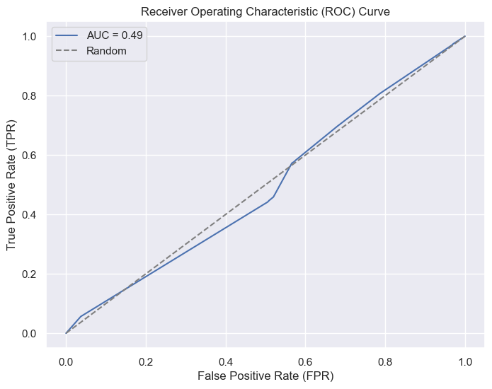

```python
# Calculate ROC curve
fpr, tpr, thresholds = roc_curve(y_test, y_probs)

# Plot ROC curve
plt.figure(figsize=(8, 6))
plt.plot(fpr, tpr, label=f'AUC = {auc_roc_score:.2f}')
plt.plot([0, 1], [0, 1], linestyle='--', color='gray', label='Random')
plt.title('Receiver Operating Characteristic (ROC) Curve')
plt.xlabel('False Positive Rate (FPR)')
plt.ylabel('True Positive Rate (TPR)')
plt.legend()
plt.show()
```

```python
### REFERENCES: AUC-ROC https://www.geeksforgeeks.org/auc-roc-curve/
### https://www.analyticsvidhya.com/blog/2021/07/metrics-to-evaluate-your-classification-model-to-take-the-right-decisions/
```

```python
import imblearn
```

```python
from sklearn.model_selection import cross_val_score
from sklearn.model_selection import RepeatedStratifiedKFold
from sklearn.tree import DecisionTreeClassifier
from imblearn.over_sampling import SMOTE
```

```python
X=df_train_new.drop(columns=['TARGET'])

y=df_train_new['TARGET']
```

## Apply SMOTE

```python
# Transform the dataset
oversample = SMOTE()
X, y = oversample.fit_resample(X, y)
```

```python
y.value_counts()
```

```
TARGET
1    243016
0    243016
Name: count, dtype: int64
```

```python
X_train, X_test, y_train, y_test = train_test_split(X, y, test_size=0.2, random_state=42)
```

#### SMOTE: One approach to addressing imbalanced datasets is to oversample the minority class.

#### The simplest approach involves duplicating examples in the minority class, although these examples don’t add any new information to the model. Instead, new examples can be synthesized from the existing examples. This is a type of data augmentation for the minority class and is referred to as the Synthetic Minority Oversampling Technique, or SMOTE for short. Specifically, a random example from the minority class is first chosen. Then k of the nearest neighbors for that example are found (typically k=5). A randomly selected neighbor is chosen and a synthetic example is created at a randomly selected point between the two examples in feature space.The approach is effective because new synthetic examples from the minority class are created that are plausible, that is, are relatively close in feature space to existing examples from the minority class.

```python
## Reference:https://machinelearningmastery.com/smote-oversampling-for-imbalanced-classification/
```

```python
models_dict = {'Model1': RandomForestClassifier(random_state=42), 'Model2':LogisticRegression(), 'Model3': DecisionTreeClassifier()}
```

```python
models_dict.items()
```

```
dict_items([('Model1', RandomForestClassifier(random_state=42)), ('Model2', LogisticRegression()), ('Model3', DecisionTreeClassifier())])
```

### Parameters:

#### - Models: A dictionary containing model names as keys and corresponding model instances as values.

#### - X_train, X_test, y_train, y_test: Training and testing datasets.

### FUNCTION FOR APPLYING SMOTE ON ALL MODELS

```python
def Classification_models(models, X_train, X_test, y_train, y_test):
    """
    Evaluate three machine learning models and provide F1-score, confusion matrix, and ROC-AUC curve.

    Returns:
    - None (prints metrics for each model)
    """

    for model_name, model in models.items():
        # Train the model
        model.fit(X_train, y_train)

        # Predictions
        y_pred = model.predict(X_test)

        # F1-score
        f1 = f1_score(y_test, y_pred, average='weighted')
        print(f"\n{model_name} F1-Score: {f1:.4f}")

        # Confusion Matrix
        cm = confusion_matrix(y_test, y_pred)
        print(f"\n{model_name} Confusion Matrix:")
        print(cm)

        # ROC-AUC Curve
        if len(np.unique(y_train)) > 2:
            # For multiclass classification, use one-vs-all strategy
            y_test_bin = label_binarize(y_test, classes=np.unique(y_train))
            n_classes = y_test_bin.shape[1]

            # Compute ROC curve and ROC area for each class
            fpr = dict()
            tpr = dict()
            roc_auc = dict()

            for i in range(n_classes):
                fpr[i], tpr[i], _ = roc_curve(y_test_bin[:, i], model.predict_proba(X_test)[:, i])
                roc_auc[i] = auc(fpr[i], tpr[i])

            # Plot ROC curve
            plt.figure(figsize=(8, 6))

            colors = cycle(['aqua', 'darkorange', 'cornflowerblue'])
            for i, color in zip(range(n_classes), colors):
                plt.plot(fpr[i], tpr[i], color=color, lw=2, label=f'Class {i} (AUC = {roc_auc[i]:.2f})')

            plt.plot([0, 1], [0, 1], color='navy', lw=2, linestyle='--')
            plt.xlim([0.0, 1.0])
            plt.ylim([0.0, 1.05])
            plt.xlabel('False Positive Rate')
            plt.ylabel('True Positive Rate')
            plt.title(f'{model_name} ROC-AUC Curve')
            plt.legend(loc="lower right")
            plt.show()

        else:
            # For binary classification
            fpr, tpr, thresholds = roc_curve(y_test, model.predict_proba(X_test)[:, 1])
            roc_auc = auc(fpr, tpr)

            # Plot ROC curve
            plt.figure(figsize=(8, 6))
            plt.plot(fpr, tpr, color='darkorange', lw=2, label=f'AUC = {roc_auc:.2f}')
            plt.plot([0, 1], [0, 1], color='navy', lw=2, linestyle='--')
            plt.xlim([0.0, 1.0])
            plt.ylim([0.0, 1.05])
            plt.xlabel('False Positive Rate')
            plt.ylabel('True Positive Rate')
            plt.title(f'{model_name} ROC-AUC Curve')
            plt.legend(loc="lower right")
            plt.show()
```

### APPLYING SMOTE ON THREE MODELS

#### RandomForestClassifier, LogisticRegression(), DecisionTreeClassifier()

```
Model1 F1-Score: 0.9556

Model1 Confusion Matrix:
[[48494    15]
 [ 4289 44409]]
```

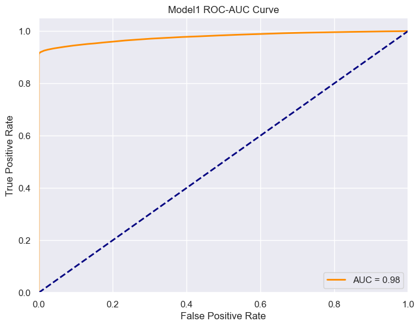

```
Model2 F1-Score: 0.5139

Model2 Confusion Matrix:
[[20264 28245]
 [18527 30171]]
```

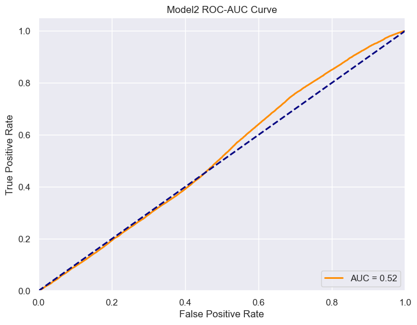

```
Model3 F1-Score: 0.9068

Model3 Confusion Matrix:
[[43531  4978]
 [ 4077 44621]]
```

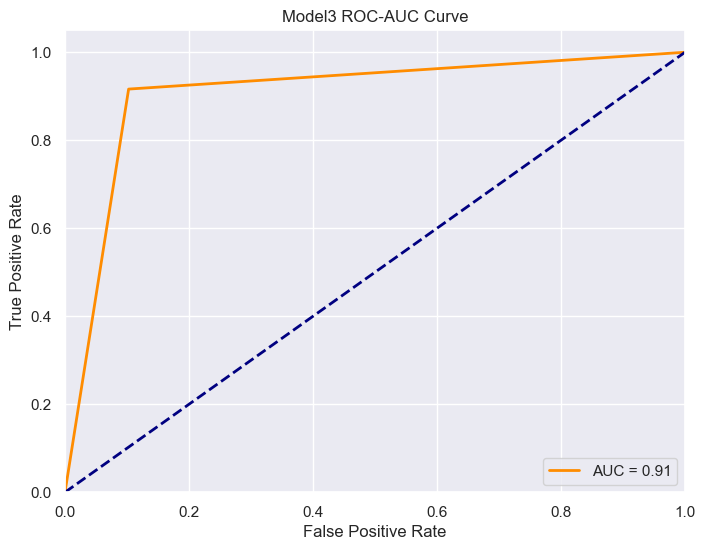

```python
Classification_models(models_dict, X_train, X_test, y_train, y_test)
```

#### CROSS VALIDATION SCORE OF THREE MODELS

#### Cross-validation is a procedure used to avoid overfitting and estimate the skill of the model on new data.

#### The mean score gives the accuracy of the model.

```python
def Cross_validation_models(models, X,y,cv=5):
# Performing cross-validation
    for model_name, model in models.items():
        cv_scores = cross_val_score(model, X, y, cv=5)  # here cv is the number of folds


        # Display cross-validation scores
        print("Cross-Validation Scores :", cv_scores)

        # The mean cross-validation score
        mean_cv_score = cv_scores.mean()
        print("Mean Cross-Validation Score:", mean_cv_score)
```

```python
Cross_validation_models(models_dict, X,y,cv=5)
```

[output not shown]

## CONCLUSION

```python
## Create html (Code for nb.convert)
```

```python
!jupyter nbconvert --to html Project_Scoring_Model_2026.ipynb
```

```python
### References:
### https://careerfoundry.com/en/blog/data-analytics/what-is-logistic-regression/
### https://serokell.io/blog/random-forest-classification
### https://www.tutorialspoint.com/machine_learning_with_python/classification_algorithms_decision_tree.htm
### https://datagy.io/sklearn-decision-tree-classifier/
### https://www.analyticsvidhya.com/blog/2021/07/metrics-to-evaluate-your-classification-model-to-take-the-right-decisions/
### Reference: https://towardsdatascience.com/cross-validation-explained-evaluating-estimator-performance-e51e5430ff85#How%20to%20Tackle%20Problem%20of%20Overfitting
```

## ---- END -----